# Meta-Analytic Structural Equation Modeling

Mike Cheung

8-10 Feb 2023 (Day 3, Session 2)

# Examples and applications

## Example 3: A mediation model

- Schutte, Keng, and Cheung (2021)[^1] examined the association among dispositional mindfulness, gratitude, and emotional intelligence via a mediation model with 41 samples.
- Although we may individually meta-analyze the bivariate relationships between EI and mindfulness, EI and gratitude, and mindfulness and gratitude, these results cannot tell us the psychological mechanism. Researchers want to address the mediating role of EI.
- Another feature of this study is that there is no study including all three variables. Therefore, this study can address research questions beyond primary studies. However, one limitation is that there may be a large degree of heterogeneity. Future studies may test the validity of the mediation model by including all three variables.

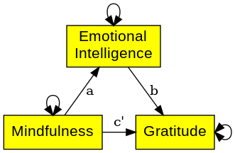

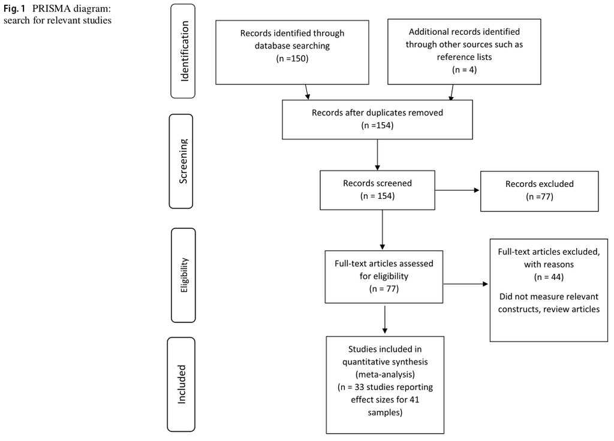

Schutte, Keng, and Cheung (2021), Figure 1

## Data preparation

- An interesting feature of this dataset is that each study only examines the bivariate relationship. MASEM allows testing theories beyond the primary studies’ bivariate relationship.

```r
library(metaSEM)

## Load the library to read the XLSX file
library(readxl)

## Read the study characteristics
my.df <- read_xlsx("Schutte21.xlsx", sheet="Sheet 1")

head(my.df)
```

```
## # A tibble: 6 × 10
##   Study_name  Effec…¹     N Type_…² Type_…³ Mindf…⁴   Age Perce…⁵ Sample Publi…⁶
##   <chr>         <dbl> <dbl> <chr>   <chr>   <chr>   <dbl>   <dbl> <chr>  <chr>
## 1 Aras, 2015     0.39   100 mindfu… trait   MAAS       NA      55 emplo… unpubl…
## 2 Bao et al.…    0.34   380 mindfu… trait   MAAS       27      59 commu… publis…
## 3 Bravo et a…    0.13    83 mindfu… trait   CAMM       10      52 stude… unpubl…
## 4 Brown and …    0.46   313 mindfu… trait   MAAS       20      66 stude… publis…
## 5 Brown and …    0.42   327 mindfu… trait   MAAS       20      64 stude… publis…
## 6 Brown and …    0.37   207 mindfu… trait   MAAS       19      62 stude… publis…
## # … with abbreviated variable names ¹Effect_size, ²Type_of_Association,
## #   ³Type_of_EI, ⁴Mindfulness_Scale, ⁵Percent_female, ⁶Publication_status
```

```r
table(my.df$Type_of_Association)
```

```
##
##   emotional intelligence and gratitude mindfulness and emotional intelligence
##                                      7                                     26
##              mindfulness and gratitude
##                                      8
```

## A function to convert rows into a 3x3 correlation matrix

```r
# |             | Mindfulness | EI       | Gratitude |
# |-------------+-------------+----------+-----------|
# | Mindfulness | 1.0         |          |           |
# | EI          | mat[2,1]    | 1.0      |           |
# | Gratitude   | mat[3,1]    | mat[3,2] |       1.0 |

create.matrix <- function(x, type=c("mindfulness and emotional intelligence",
                                    "mindfulness and gratitude",
                                    "emotional intelligence and gratitude")) {
  mat <- matrix(NA, ncol=3, nrow=3)
  diag(mat) <- 1
  type <- match(type,
                c("mindfulness and emotional intelligence",
                  "mindfulness and gratitude",
                  "emotional intelligence and gratitude"))
  switch(type,
         "mindfulness and emotional intelligence" = mat[1, 2] <- mat[2, 1] <- unlist(x),
         "mindfulness and gratitude" = mat[1, 3] <- mat[3, 1] <- unlist(x),
         "emotional intelligence and gratitude" = mat[2, 3] <- mat[3, 2] <- unlist(x))
  mat
}

my.vars <- c("Mindfulness", "EI", "Gratitude")

my.cor <- lapply(split(my.df, seq(nrow(my.df))),
                 function(x) create.matrix(x["Effect_size"], x["Type_of_Association"]))

## Add the dimnames for reference
my.cor <- lapply(my.cor, function(x) {dimnames(x) <- list(my.vars, my.vars); x}  )

## Add the study names for reference
names(my.cor) <- my.df$Study_name

## Correlation matrices in the analysis
head(my.cor)
```

```
## $`Aras, 2015`
##             Mindfulness   EI Gratitude
## Mindfulness        1.00 0.39        NA
## EI                 0.39 1.00        NA
## Gratitude            NA   NA         1
##
## $`Bao et al., 2015`
##             Mindfulness   EI Gratitude
## Mindfulness        1.00 0.34        NA
## EI                 0.34 1.00        NA
## Gratitude            NA   NA         1
##
## $`Bravo et al., 2015`
##             Mindfulness   EI Gratitude
## Mindfulness        1.00 0.13        NA
## EI                 0.13 1.00        NA
## Gratitude            NA   NA         1
##
## $`Brown and Ryan, 2003_Sample A`
##             Mindfulness   EI Gratitude
## Mindfulness        1.00 0.46        NA
## EI                 0.46 1.00        NA
## Gratitude            NA   NA         1
##
## $`Brown and Ryan, 2003_Sample B`
##             Mindfulness   EI Gratitude
## Mindfulness        1.00 0.42        NA
## EI                 0.42 1.00        NA
## Gratitude            NA   NA         1
##
## $`Brown and Ryan, 2003_Sample C`
##             Mindfulness   EI Gratitude
## Mindfulness        1.00 0.37        NA
## EI                 0.37 1.00        NA
## Gratitude            NA   NA         1
```

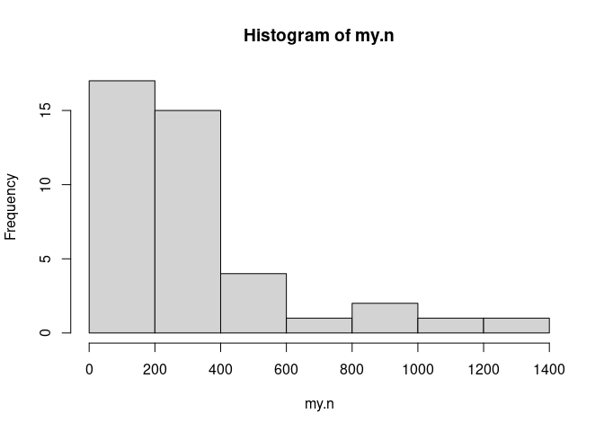

```r
## Sample sizes
my.n <- my.df$N
hist(my.n)
```

```r
## Number of studies in each cell
pattern.na(my.cor, show.na = FALSE)
```

```
##             Mindfulness EI Gratitude
## Mindfulness          41 26         8
## EI                   26 41         7
## Gratitude             8  7        41
```

```r
## Total sample sizes in each cell
pattern.n(my.cor, my.n)
```

```
##             Mindfulness    EI Gratitude
## Mindfulness       13497  6369      3130
## EI                 6369 13497      3998
## Gratitude          3130  3998     13497
```

## First-stage of analysis

```r
## Stage 1 analysis: find an average correlation matrix
stage1 <- tssem1(my.cor, my.n, method="REM")
summary(stage1)
```

```
##
## Call:
## meta(y = ES, v = acovR, RE.constraints = Diag(paste0(RE.startvalues,
##     "*Tau2_", 1:no.es, "_", 1:no.es)), RE.lbound = RE.lbound,
##     I2 = I2, model.name = model.name, suppressWarnings = TRUE,
##     silent = silent, run = run)
##
## 95% confidence intervals: z statistic approximation (robust=FALSE)
## Coefficients:
##              Estimate  Std.Error     lbound     ubound z value  Pr(>|z|)
## Intercept1  0.4007062  0.0342472  0.3335830  0.4678294 11.7004 < 2.2e-16 ***
## Intercept2  0.2188135  0.0290679  0.1618414  0.2757855  7.5277 5.174e-14 ***
## Intercept3  0.3123689  0.0416955  0.2306472  0.3940906  7.4917 6.795e-14 ***
## Tau2_1_1    0.0260509  0.0089658  0.0084783  0.0436236  2.9056  0.003666 **
## Tau2_2_2    0.0038767  0.0030542 -0.0021094  0.0098628  1.2693  0.204327
## Tau2_3_3    0.0095986  0.0058884 -0.0019424  0.0211396  1.6301  0.103083
## ---
## Signif. codes:  0 '***' 0.001 '**' 0.01 '*' 0.05 '.' 0.1 ' ' 1
##
## Q statistic on the homogeneity of effect sizes: 262.1055
## Degrees of freedom of the Q statistic: 38
## P value of the Q statistic: 0
##
## Heterogeneity indices (based on the estimated Tau2):
##                              Estimate
## Intercept1: I2 (Q statistic)   0.9209
## Intercept2: I2 (Q statistic)   0.5784
## Intercept3: I2 (Q statistic)   0.7998
##
## Number of studies (or clusters): 41
## Number of observed statistics: 41
## Number of estimated parameters: 6
## Degrees of freedom: 35
## -2 log likelihood: -44.57614
## OpenMx status1: 0 ("0" or "1": The optimization is considered fine.
## Other values may indicate problems.)
```

## Average correlation matrix

```r
meanR <- vec2symMat(coef(stage1, select = "fixed"), diag = FALSE)
dimnames(meanR) <- list(my.vars, my.vars)
meanR
```

```
##             Mindfulness        EI Gratitude
## Mindfulness   1.0000000 0.4007062 0.2188135
## EI            0.4007062 1.0000000 0.3123689
## Gratitude     0.2188135 0.3123689 1.0000000
```

## Absolute heterogeneity variance: tau^2

```r
tau2 <- vec2symMat(coef(stage1, select = "random"), diag = FALSE)
dimnames(tau2) <- list(my.vars, my.vars)
tau2
```

```
##             Mindfulness          EI   Gratitude
## Mindfulness  1.00000000 0.026050950 0.003876740
## EI           0.02605095 1.000000000 0.009598596
## Gratitude    0.00387674 0.009598596 1.000000000
```

## Relative heterogeneity index: I^2

```r
I2 <- vec2symMat(summary(stage1)$I2.values[, "Estimate"], diag = FALSE)
dimnames(I2) <- list(my.vars, my.vars)
I2
```

```
##             Mindfulness       EI Gratitude
## Mindfulness   1.0000000 0.920929 0.5783717
## EI            0.9209290 1.000000 0.7998260
## Gratitude     0.5783717 0.799826 1.0000000
```

## Second stage of analysis

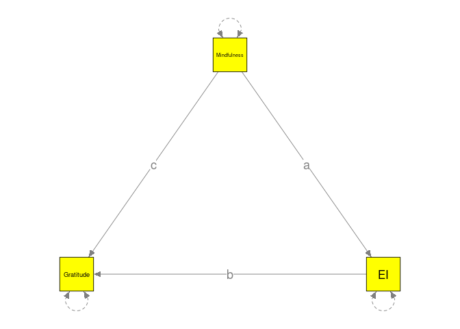

```r
## Proposed model
model1 <- "Gratitude ~ c*Mindfulness + b*EI
           EI ~ a*Mindfulness
           Mindfulness ~~ 1*Mindfulness
           ## Define direct and indirect effects
           Direct := c
           Indirect := a*b"

plot(model1, color="yellow")
```

```r
RAM1<- lavaan2RAM(model1, obs.variables = my.vars)
RAM1
```

```
## $A
##             Mindfulness EI      Gratitude
## Mindfulness "0"         "0"     "0"
## EI          "0.1*a"     "0"     "0"
## Gratitude   "0.1*c"     "0.1*b" "0"
##
## $S
##             Mindfulness EI             Gratitude
## Mindfulness "1"         "0"            "0"
## EI          "0"         "0.5*EIWITHEI" "0"
## Gratitude   "0"         "0"            "0.5*GratitudeWITHGratitude"
##
## $F
##             Mindfulness EI Gratitude
## Mindfulness           1  0         0
## EI                    0  1         0
## Gratitude             0  0         1
##
## $M
##   Mindfulness EI Gratitude
## 1           0  0         0
##
## $mxalgebras
## $mxalgebras$Direct
## mxAlgebra 'Direct'
## $formula:  c
## $result: (not yet computed) <0 x 0 matrix>
## dimnames: NULL
##
## $mxalgebras$Indirect
## mxAlgebra 'Indirect'
## $formula:  a * b
## $result: (not yet computed) <0 x 0 matrix>
## dimnames: NULL
```

## Stage 2 analysis: fit the path model

- Indirect = a*b
- Direct = c
- Likelihood-based CI: intervals.type = “LB”

```r
stage2 <- tssem2(stage1, RAM=RAM1, intervals.type = "LB")
summary(stage2)
```

```
##
## Call:
## wls(Cov = pooledS, aCov = aCov, n = tssem1.obj$total.n, RAM = RAM,
##     Amatrix = Amatrix, Smatrix = Smatrix, Fmatrix = Fmatrix,
##     diag.constraints = diag.constraints, cor.analysis = cor.analysis,
##     intervals.type = intervals.type, mx.algebras = mx.algebras,
##     mxModel.Args = mxModel.Args, subset.variables = subset.variables,
##     model.name = model.name, suppressWarnings = suppressWarnings,
##     silent = silent, run = run)
##
## 95% confidence intervals: Likelihood-based statistic
## Coefficients:
##   Estimate Std.Error   lbound   ubound z value Pr(>|z|)
## a 0.400706        NA 0.333466 0.467842      NA       NA
## b 0.267667        NA 0.166085 0.369322      NA       NA
## c 0.111558        NA 0.028737 0.190505      NA       NA
##
## mxAlgebras objects (and their 95% likelihood-based CIs):
##                   lbound  Estimate    ubound
## Direct[1,1]   0.02873693 0.1115576 0.1905046
## Indirect[1,1] 0.06580411 0.1072559 0.1559166
##
## Goodness-of-fit indices:
##                                               Value
## Sample size                                13497.00
## Chi-square of target model                     0.00
## DF of target model                             0.00
## p value of target model                        0.00
## Number of constraints imposed on "Smatrix"     0.00
## DF manually adjusted                           0.00
## Chi-square of independence model             249.69
## DF of independence model                       3.00
## RMSEA                                          0.00
## RMSEA lower 95% CI                             0.00
## RMSEA upper 95% CI                             0.00
## SRMR                                           0.00
## TLI                                            -Inf
## CFI                                            1.00
## AIC                                            0.00
## BIC                                            0.00
## OpenMx status1: 0 ("0" or "1": The optimization is considered fine.
## Other values indicate problems.)
```

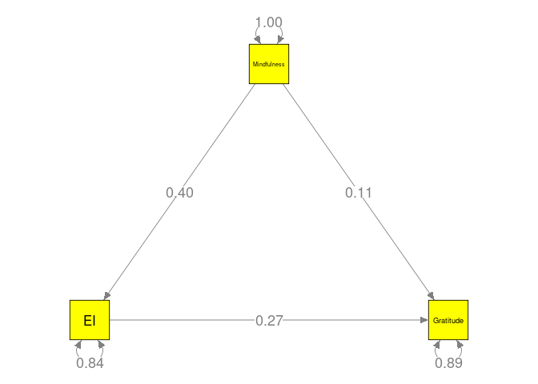

```r
plot(stage2, color="yellow")
```

## Testing the direct effect equals the indirect effect

- The previous analysis suggests that the magnitude of the direct effect is comparable to that of the indirect effect. We may formally run a test to verify it.
- We add a nonlinear constraint `c == a*b` to test the above hypothesis
- The LR test is $\chi^2(df=1) = 0.005, p=.94$, suggesting that there is no evidence to reject the hypothesis that the direct effect equals the indirect effect.

```r
## Model with direct effect equals indirect effect
model2 <- "Gratitude ~ c*Mindfulness + b*EI
           EI ~ a*Mindfulness
           Mindfulness ~~ 1*Mindfulness
           ## Define direct and indirect effects
           Direct := c
           Indirect := a*b
           ## Add a constraint to ensure c = a*b
           c == a*b
"

RAM2 <- lavaan2RAM(model2, obs.variables = my.vars)
RAM2
```

```
## $A
##             Mindfulness EI      Gratitude
## Mindfulness "0"         "0"     "0"
## EI          "0.1*a"     "0"     "0"
## Gratitude   "0.1*c"     "0.1*b" "0"
##
## $S
##             Mindfulness EI             Gratitude
## Mindfulness "1"         "0"            "0"
## EI          "0"         "0.5*EIWITHEI" "0"
## Gratitude   "0"         "0"            "0.5*GratitudeWITHGratitude"
##
## $F
##             Mindfulness EI Gratitude
## Mindfulness           1  0         0
## EI                    0  1         0
## Gratitude             0  0         1
##
## $M
##   Mindfulness EI Gratitude
## 1           0  0         0
##
## $mxalgebras
## $mxalgebras$Direct
## mxAlgebra 'Direct'
## $formula:  c
## $result: (not yet computed) <0 x 0 matrix>
## dimnames: NULL
##
## $mxalgebras$Indirect
## mxAlgebra 'Indirect'
## $formula:  a * b
## $result: (not yet computed) <0 x 0 matrix>
## dimnames: NULL
##
## $mxalgebras$constraint1
## MxConstraint 'constraint1'
## $formula:  c == a * b
```

## Stage 2 analysis: fit the path model

- Indirect = a*b
- Direct = c
- Likelihood-based CI: intervals.type = “LB”

```r
stage2b <- tssem2(stage1, RAM=RAM2, intervals.type = "LB")
summary(stage2)
```

```
##
## Call:
## wls(Cov = pooledS, aCov = aCov, n = tssem1.obj$total.n, RAM = RAM,
##     Amatrix = Amatrix, Smatrix = Smatrix, Fmatrix = Fmatrix,
##     diag.constraints = diag.constraints, cor.analysis = cor.analysis,
##     intervals.type = intervals.type, mx.algebras = mx.algebras,
##     mxModel.Args = mxModel.Args, subset.variables = subset.variables,
##     model.name = model.name, suppressWarnings = suppressWarnings,
##     silent = silent, run = run)
##
## 95% confidence intervals: Likelihood-based statistic
## Coefficients:
##   Estimate Std.Error   lbound   ubound z value Pr(>|z|)
## a 0.400706        NA 0.333466 0.467842      NA       NA
## b 0.267667        NA 0.166085 0.369322      NA       NA
## c 0.111558        NA 0.028737 0.190505      NA       NA
##
## mxAlgebras objects (and their 95% likelihood-based CIs):
##                   lbound  Estimate    ubound
## Direct[1,1]   0.02873693 0.1115576 0.1905046
## Indirect[1,1] 0.06580411 0.1072559 0.1559166
##
## Goodness-of-fit indices:
##                                               Value
## Sample size                                13497.00
## Chi-square of target model                     0.00
## DF of target model                             0.00
## p value of target model                        0.00
## Number of constraints imposed on "Smatrix"     0.00
## DF manually adjusted                           0.00
## Chi-square of independence model             249.69
## DF of independence model                       3.00
## RMSEA                                          0.00
## RMSEA lower 95% CI                             0.00
## RMSEA upper 95% CI                             0.00
## SRMR                                           0.00
## TLI                                            -Inf
## CFI                                            1.00
## AIC                                            0.00
## BIC                                            0.00
## OpenMx status1: 0 ("0" or "1": The optimization is considered fine.
## Other values indicate problems.)
```

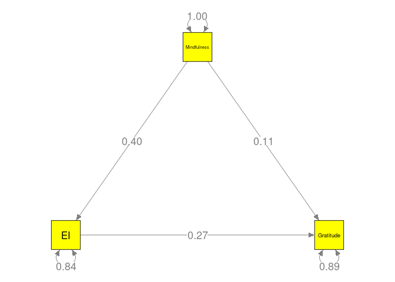

```r
plot(stage2b, color="yellow")
```

## Let’s check if c = a*b

```r
mxEval(c-a*b, stage2b$mx.fit)
```

```
##              [,1]
## [1,] 2.444193e-11
```

```r
## Compare the models with and without c=a*b
## df=1 because we are comparing 1 constraint.
anova(stage2, stage2b)
```

```
##                 base         comparison ep     minus2LL df      AIC      diffLL
## 1 TSSEM2 Correlation               <NA>  3 2.893374e-24 -3 6.000000          NA
## 2 TSSEM2 Correlation TSSEM2 Correlation  3 5.222545e-03 -2 6.005223 0.005222545
##   diffdf         p
## 1     NA        NA
## 2      1 0.9423893
```

# Parameter-based MASEM

- The approaches covered so far are known as correlation-based MASEM–correlation matrices are synthesized first, then structural models are fitted.
- An alternative is called parameter-based MASEM (Cheung & cheung, 2016).[^2]:
  - It fits structural equation models and gets each study’s parameter estimates and their sampling covariance matrices.
  - A multivariate meta-analysis is conducted using parameter estimates as effect sizes.
- Advantage: random effects are on the parameters, e.g., indirect and direct effects.
- Disadvantages:
  - Complete data are required.
  - No model fit indicated on the proposed model.

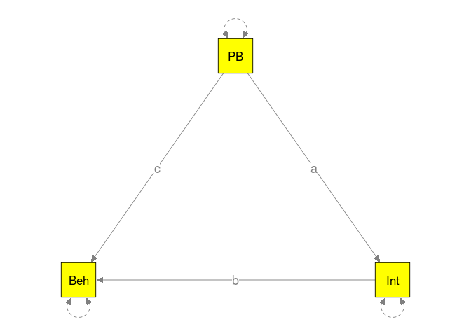

```r
model <- "Beh ~ b*Int + c*PB
          Int ~ a*PB
          PB ~~ 1*PB"
plot(model, col="yellow")
```

```r
## Load the dataset
load("Hagger18.Rdata")

head(Hagger18)
```

```
## $data
## $data$`3`
##       Beh  Int    PB
## Beh 1.000 0.65 0.709
## Int 0.650 1.00 0.650
## PB  0.709 0.65 1.000
##
## $data$`19`
##      Beh  Int   PB
## Beh 1.00 0.84 0.87
## Int 0.84 1.00 0.94
## PB  0.87 0.94 1.00
##
## $data$`20`
##       Beh   Int    PB
## Beh 1.000 0.534 0.768
## Int 0.534 1.000 0.540
## PB  0.768 0.540 1.000
##
## $data$`22`
##      Beh  Int   PB
## Beh 1.00 0.55 0.54
## Int 0.55 1.00 0.32
## PB  0.54 0.32 1.00
##
## $data$`25`
##      Beh  Int   PB
## Beh 1.00 0.53 0.52
## Int 0.53 1.00 0.78
## PB  0.52 0.78 1.00
##
## $data$`26`
##      Beh  Int   PB
## Beh 1.00 0.53 0.54
## Int 0.53 1.00 0.54
## PB  0.54 0.54 1.00
##
## $data$`29`
##      Beh  Int   PB
## Beh 1.00 0.64 0.63
```

[output cut: 127 more lines]

```
## PB  0.81 0.78 1.00
##
## $data$`81`
##      Beh  Int   PB
## Beh 1.00 0.52 0.45
## Int 0.52 1.00 0.64
## PB  0.45 0.64 1.00
##
##
## $n
##  [1]  413  118   41  146  192  413 1403  133  523  596  174  272   85  365  620
## [16]  743  109   79  273   95  236  153  103  225  139  146   54  225   62
##
## $beh_freq_high
##  [1] 1 0 1 1 1 1 1 1 1 1 1 1 1 1 0 0 1 1 1 0 1 1 1 1 1 1 1 1 1
```

## Estimate the direct and indirect effects and their sampling covariance matrices

```r
## The variables are arranged as the outcome, mediator, and predictor: Beh, Int, and PB.
Indirect.eff <- indirectEffect(Hagger18$data, Hagger18$n)

## Add behavior frequency to the data
Indirect.eff <- data.frame(Indirect.eff, beh_freq_high=Hagger18$beh_freq_high)

## Show the first few studies
head(Indirect.eff)
```

```
##       ind_eff   dir_eff      ind_var   ind_dir_cov     dir_var beh_freq_high
## 3  0.23971461 0.5585981 0.0012158465 -0.0010127721 0.001890922             1
## 19 0.20669102 0.7963369 0.0256034746 -0.0126145194 0.007139375             0
## 20 0.09709888 0.7230498 0.0054607198 -0.0033732871 0.007436056             1
## 22 0.14246754 0.4296310 0.0016172775 -0.0006532121 0.004438969             1
## 25 0.26640325 0.2926724 0.0064450809 -0.0065081243 0.010790892             1
## 26 0.19485689 0.3841558 0.0009136998 -0.0007736947 0.002370634             1
```

## Multivariate meta-analysis on the direct and indirect effects

```r
## Random-effects model
IE0 <- meta(y=cbind(ind_eff, dir_eff),
            v=cbind(ind_var, ind_dir_cov, dir_var),
            data=Indirect.eff,
            model.name = "Random")
summary(IE0)
```

```
##
## Call:
## meta(y = cbind(ind_eff, dir_eff), v = cbind(ind_var, ind_dir_cov,
##     dir_var), data = Indirect.eff, model.name = "Random")
##
## 95% confidence intervals: z statistic approximation (robust=FALSE)
## Coefficients:
##              Estimate  Std.Error     lbound     ubound z value  Pr(>|z|)
## Intercept1  0.1453716  0.0203468  0.1054926  0.1852507  7.1447 9.019e-13 ***
## Intercept2  0.4275448  0.0409088  0.3473651  0.5077246 10.4512 < 2.2e-16 ***
## Tau2_1_1    0.0095735  0.0030380  0.0036191  0.0155278  3.1513 0.0016257 **
## Tau2_2_1    0.0027014  0.0046064 -0.0063269  0.0117297  0.5865 0.5575692
## Tau2_2_2    0.0432142  0.0128722  0.0179851  0.0684433  3.3572 0.0007875 ***
## ---
## Signif. codes:  0 '***' 0.001 '**' 0.01 '*' 0.05 '.' 0.1 ' ' 1
##
## Q statistic on the homogeneity of effect sizes: 1031.864
## Degrees of freedom of the Q statistic: 56
## P value of the Q statistic: 0
##
## Heterogeneity indices (based on the estimated Tau2):
##                              Estimate
## Intercept1: I2 (Q statistic)   0.9044
## Intercept2: I2 (Q statistic)   0.9349
##
## Number of studies (or clusters): 29
## Number of observed statistics: 58
## Number of estimated parameters: 5
## Degrees of freedom: 53
## -2 log likelihood: -50.01425
## OpenMx status1: 0 ("0" or "1": The optimization is considered fine.
## Other values may indicate problems.)
```

## Variance-covariance matrix of the random effects

```r
VarCorr(IE0)
```

```
##             [,1]        [,2]
## [1,] 0.009573474 0.002701423
## [2,] 0.002701423 0.043214170
```

```r
## Correlation matrix of the random effects: small correlation
cov2cor(VarCorr(IE0))
```

```
##           [,1]      [,2]
## [1,] 1.0000000 0.1328143
## [2,] 0.1328143 1.0000000
```

## Plot the effect sizes

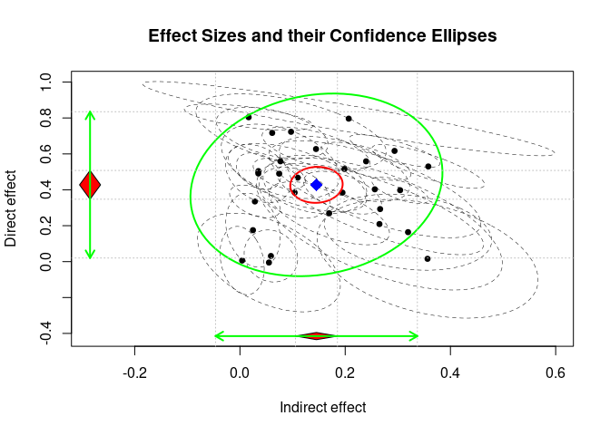

```r
plot(IE0, axis.labels = c("Indirect effect", "Direct effect"))
```

## Mixed-effects model with behavior frequency as a moderator

- `beh_freq` is not significant in predicting the indirect and direct effects

```r
IE1 <- meta(y=cbind(ind_eff, dir_eff),
            v=cbind(ind_var, ind_dir_cov, dir_var),
            x=beh_freq_high,
            data=Indirect.eff,
            model.name = "Moderator_beh")
summary(IE1)
```

```
##
## Call:
## meta(y = cbind(ind_eff, dir_eff), v = cbind(ind_var, ind_dir_cov,
##     dir_var), x = beh_freq_high, data = Indirect.eff, model.name = "Moderator_beh")
##
## 95% confidence intervals: z statistic approximation (robust=FALSE)
## Coefficients:
##              Estimate  Std.Error     lbound     ubound z value  Pr(>|z|)
## Intercept1  0.1406059  0.0577021  0.0275118  0.2537000  2.4368 0.0148197 *
## Intercept2  0.4604307  0.1076665  0.2494083  0.6714532  4.2765 1.899e-05 ***
## Slope1_1    0.0053929  0.0614966 -0.1151382  0.1259240  0.0877 0.9301194
## Slope2_1   -0.0383525  0.1163142 -0.2663242  0.1896192 -0.3297 0.7416029
## Tau2_1_1    0.0095301  0.0030421  0.0035678  0.0154925  3.1328 0.0017315 **
## Tau2_2_1    0.0026812  0.0045911 -0.0063172  0.0116795  0.5840 0.5592234
## Tau2_2_2    0.0431205  0.0128488  0.0179373  0.0683038  3.3560 0.0007908 ***
## ---
## Signif. codes:  0 '***' 0.001 '**' 0.01 '*' 0.05 '.' 0.1 ' ' 1
##
## Q statistic on the homogeneity of effect sizes: 1031.864
## Degrees of freedom of the Q statistic: 56
## P value of the Q statistic: 0
##
## Explained variances (R2):
##                               y1     y2
## Tau2 (no predictor)    0.0095735 0.0432
## Tau2 (with predictors) 0.0095301 0.0431
## R2                     0.0045263 0.0022
##
## Number of studies (or clusters): 29
## Number of observed statistics: 58
## Number of estimated parameters: 7
## Degrees of freedom: 51
## -2 log likelihood: -50.13325
## OpenMx status1: 0 ("0" or "1": The optimization is considered fine.
## Other values may indicate problems.)
```

```r
## Test the statistical significance between the models
anova(IE1, IE0)
```

```
##            base comparison ep  minus2LL df       AIC    diffLL diffdf        p
## 1 Moderator_beh       <NA>  7 -50.13325 51 -36.13325        NA     NA       NA
## 2 Moderator_beh     Random  5 -50.01425 53 -40.01425 0.1189926      2 0.942239
```

# Tips in MASEM

- This session will discuss some common issues and tips in MASEM.

## It takes a long time to run my models!

- We may speed up the analyses by using more cores available in your computers.

```r
library(metaSEM)

## Show how many cores are in my computer
parallel::detectCores()
```

```
## [1] 8
```

```r
## Use all cores-2, i.e., keep 2 cores for other operations.
mxOption(key='Number of Threads', value=parallel::detectCores()-2)
```

### Why are my data strings not numeric?

- There may be *white space* characters in Excel if we accidentally add spaces before or after the numbers. These variables will be read as strings instead of numbers. We may use `as.numeric()` function to convert them to numbers.

```r
## x is a string vector
x <- c(10.1, 23.4, "2.1 ", " 3.4", "\t4.2", "3.1\n")
x
```

```
## [1] "10.1"  "23.4"  "2.1 "  " 3.4"  "\t4.2" "3.1\n"
```

```r
is.numeric(x)
```

```
## [1] FALSE
```

```r
is.character(x)
```

```
## [1] TRUE
```

```r
## Convert it to numeric
y <- as.numeric(x)
y
```

```
## [1] 10.1 23.4  2.1  3.4  4.2  3.1
```

```r
is.numeric(y)
```

```
## [1] TRUE
```

## How do I know if my correlation matrices are “proper”?

- There are restrictions on correlation matrices, e.g., they cannot be larger than 1, which is known as [positive definite](https://en.wikipedia.org/wiki/Definite_matrix). The results may be problematic when some correlation matrices are non-positive definite.
- We may check the definite of the matrices with `is.pd()` function.

```r
## X1 is okay
X1 <- matrix(c(1, 0.8, 0.8, 1), nrow=2)
X1
```

```
##      [,1] [,2]
## [1,]  1.0  0.8
## [2,]  0.8  1.0
```

```r
is.pd(X1)
```

```
## [1] TRUE
```

```r
## X2 is not okay, as the correlation is 1.2.
X2 <- matrix(c(1, 1.2, 1.2, 1), nrow=2)
X2
```

```
##      [,1] [,2]
## [1,]  1.0  1.2
## [2,]  1.2  1.0
```

```r
is.pd(X2)
```

```
## [1] FALSE
```

```r
## X3 is not okay, as the correlation matrix is not symmetric.
X3 <- matrix(c(1, 0.6, 0.8, 1), nrow=2)
X3
```

```
##      [,1] [,2]
## [1,]  1.0  0.8
## [2,]  0.6  1.0
```

```r
isSymmetric(X3)
```

```
## [1] FALSE
```

## What should I do when the solution is non-convergent?

- Statistical packages use iterative procedures to estimate the parameters. When the iterations are convergent (code 0 or 1 in OpenMx), we can trust the results; otherwise, we should not interpret the results.
- The results are okay:

```r
OpenMx status1: 0 ("0" or "1": The optimization is considered fine.
Other values indicate problems.)
```

- The results are not okay:

```r
OpenMx status1: 5 ("0" or "1": The optimization is considered fine.
Other values may indicate problems.)
Warning message:
In print.summary.meta(x) :
  OpenMx status1 is neither 0 or 1. You are advised to 'rerun' it again.

## Suppose the results are stored in an object called "fit"
## We may improve the fit by rerunning it with rerun().
## The default extraTries is 10.
fit <- rerun(fit, extraTries=50)
summary(fit)
```

- A common reason for non-convergent solutions is that there is [no data](https://openmx.ssri.psu.edu/node/4804) or [not enough data](https://openmx.ssri.psu.edu/node/4715). We may use the following code to check it.
- There are several options to deal with this issue:
  - Try a fixed-effects model.
  - Simplify the model by using fewer variables (see below).

```r
pattern.na(Hunter83$data, show.na=FALSE)
```

```
##               Ability Job_knowledge Work_sample Supervisor
## Ability            13            11          11         12
## Job_knowledge      11            12          10         11
## Work_sample        11            10          12         11
## Supervisor         12            11          11         13
```

## Selecting some variables in fitting SEM

- Sometimes, we may want to fit models based on different variables. It is useful if we can specify which variables to include.
- Here is an example using `Digman97` dataset. There are five variables loaded on two factors. Suppose we are interested in fitting a one-factor model with three variables.

```r
## Sample data from Digman (1997)
Digman97$data[1:2]
```

```
## $`Digman 1 (1994)`
##        A     C   ES     E    I
## A   1.00  0.62 0.41 -0.48 0.00
## C   0.62  1.00 0.59 -0.10 0.35
## ES  0.41  0.59 1.00  0.27 0.41
## E  -0.48 -0.10 0.27  1.00 0.37
## I   0.00  0.35 0.41  0.37 1.00
##
## $`Digman 2 (1994)`
##        A    C   ES     E     I
## A   1.00 0.39 0.53 -0.30 -0.05
## C   0.39 1.00 0.59  0.07  0.44
## ES  0.53 0.59 1.00  0.09  0.22
## E  -0.30 0.07 0.09  1.00  0.45
## I  -0.05 0.44 0.22  0.45  1.00
```

```r
# TSSEM
## Stage 1 TSSEM with a random-effects model
rand1 <- tssem1(Digman97$data, Digman97$n, method="REM")
summary(rand1)
```

```
##
## Call:
## meta(y = ES, v = acovR, RE.constraints = Diag(paste0(RE.startvalues,
##     "*Tau2_", 1:no.es, "_", 1:no.es)), RE.lbound = RE.lbound,
##     I2 = I2, model.name = model.name, suppressWarnings = TRUE,
##     silent = silent, run = run)
##
## 95% confidence intervals: z statistic approximation (robust=FALSE)
## Coefficients:
##                Estimate   Std.Error      lbound      ubound z value  Pr(>|z|)
## Intercept1   0.38971910  0.05429256  0.28330764  0.49613055  7.1781 7.068e-13
## Intercept2   0.43265879  0.04145136  0.35141562  0.51390197 10.4377 < 2.2e-16
## Intercept3   0.04945635  0.06071079 -0.06953461  0.16844731  0.8146   0.41529
## Intercept4   0.09603708  0.04478711  0.00825595  0.18381820  2.1443   0.03201
## Intercept5   0.42724243  0.03911620  0.35057609  0.50390878 10.9224 < 2.2e-16
## Intercept6   0.11929318  0.04106203  0.03881309  0.19977328  2.9052   0.00367
## Intercept7   0.19292425  0.04757962  0.09966991  0.28617859  4.0548 5.018e-05
## Intercept8   0.22690164  0.03240892  0.16338132  0.29042196  7.0012 2.538e-12
## Intercept9   0.18105567  0.04258855  0.09758364  0.26452770  4.2513 2.126e-05
## Intercept10  0.43614968  0.03205960  0.37331401  0.49898535 13.6043 < 2.2e-16
## Tau2_1_1     0.03648371  0.01513054  0.00682839  0.06613903  2.4113   0.01590
## Tau2_2_2     0.01963098  0.00859789  0.00277942  0.03648254  2.2832   0.02242
## Tau2_3_3     0.04571438  0.01952285  0.00745030  0.08397845  2.3416   0.01920
## Tau2_4_4     0.02236122  0.00995083  0.00285794  0.04186449  2.2472   0.02463
## Tau2_5_5     0.01729072  0.00796404  0.00168149  0.03289995  2.1711   0.02992
## Tau2_6_6     0.01815481  0.00895896  0.00059557  0.03571405  2.0264   0.04272
## Tau2_7_7     0.02604882  0.01130266  0.00389601  0.04820162  2.3047   0.02119
## Tau2_8_8     0.00988761  0.00513713 -0.00018098  0.01995619  1.9247   0.05426
## Tau2_9_9     0.01988244  0.00895053  0.00233973  0.03742515  2.2214   0.02633
## Tau2_10_10   0.01049222  0.00501578  0.00066148  0.02032296  2.0918   0.03645
##
## Intercept1  ***
## Intercept2  ***
## Intercept3
## Intercept4  *
## Intercept5  ***
## Intercept6  **
## Intercept7  ***
## Intercept8  ***
## Intercept9  ***
```

[output cut: 23 more lines]

```
## Intercept4: I2 (Q statistic)    0.8703
## Intercept5: I2 (Q statistic)    0.8797
## Intercept6: I2 (Q statistic)    0.8480
## Intercept7: I2 (Q statistic)    0.8887
## Intercept8: I2 (Q statistic)    0.7669
## Intercept9: I2 (Q statistic)    0.8590
## Intercept10: I2 (Q statistic)   0.8193
##
## Number of studies (or clusters): 14
## Number of observed statistics: 140
## Number of estimated parameters: 20
## Degrees of freedom: 120
## -2 log likelihood: -112.4196
## OpenMx status1: 0 ("0" or "1": The optimization is considered fine.
## Other values may indicate problems.)
```

## TSSEM Stage 2 analysis

- Suppose we only want to fit a one-factor model with 3 variables for illustration.

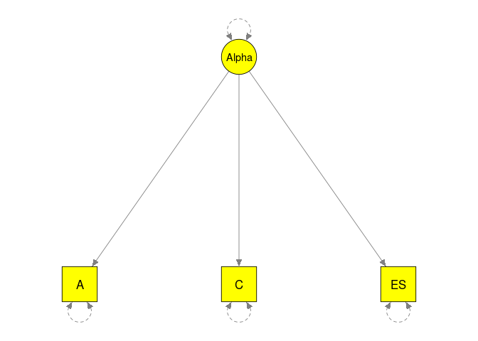

```r
model <- "## One-factor model with 3 indicators
          Alpha=~A+C+ES"
plot(model, col="yellow")
```

```r
RAM <- lavaan2RAM(model, obs.variables=c("A","C","ES"))
RAM
```

```
## $A
##       A   C   ES  Alpha
## A     "0" "0" "0" "0.1*AONAlpha"
## C     "0" "0" "0" "0.1*CONAlpha"
## ES    "0" "0" "0" "0.1*ESONAlpha"
## Alpha "0" "0" "0" "0"
##
## $S
##       A            C            ES             Alpha
## A     "0.5*AWITHA" "0"          "0"            "0"
## C     "0"          "0.5*CWITHC" "0"            "0"
## ES    "0"          "0"          "0.5*ESWITHES" "0"
## Alpha "0"          "0"          "0"            "1"
##
## $F
##    A C ES Alpha
## A  1 0  0     0
## C  0 1  0     0
## ES 0 0  1     0
##
## $M
##   A C ES Alpha
## 1 0 0  0     0
```

```r
## Use subset.variables to include variables in the analysis
rand2 <- tssem2(rand1, RAM=RAM, subset.variables=c("A","C","ES"))
summary(rand2)
```

```
##
## Call:
## wls(Cov = pooledS, aCov = aCov, n = tssem1.obj$total.n, RAM = RAM,
##     Amatrix = Amatrix, Smatrix = Smatrix, Fmatrix = Fmatrix,
##     diag.constraints = diag.constraints, cor.analysis = cor.analysis,
##     intervals.type = intervals.type, mx.algebras = mx.algebras,
##     mxModel.Args = mxModel.Args, subset.variables = subset.variables,
##     model.name = model.name, suppressWarnings = suppressWarnings,
##     silent = silent, run = run)
##
## 95% confidence intervals: z statistic approximation
## Coefficients:
##           Estimate Std.Error   lbound   ubound z value  Pr(>|z|)
## AONAlpha  0.628220  0.059860 0.510896 0.745543  10.495 < 2.2e-16 ***
## CONAlpha  0.620355  0.058846 0.505020 0.735690  10.542 < 2.2e-16 ***
## ESONAlpha 0.688706  0.064815 0.561670 0.815742  10.626 < 2.2e-16 ***
## ---
## Signif. codes:  0 '***' 0.001 '**' 0.01 '*' 0.05 '.' 0.1 ' ' 1
##
## Goodness-of-fit indices:
##                                              Value
## Sample size                                4496.00
## Chi-square of target model                    0.00
## DF of target model                            0.00
## p value of target model                       0.00
## Number of constraints imposed on "Smatrix"    0.00
## DF manually adjusted                          0.00
## Chi-square of independence model            257.46
## DF of independence model                      3.00
## RMSEA                                         0.00
## RMSEA lower 95% CI                            0.00
## RMSEA upper 95% CI                            0.00
## SRMR                                          0.00
## TLI                                           -Inf
## CFI                                           1.00
## AIC                                           0.00
## BIC                                           0.00
## OpenMx status1: 0 ("0" or "1": The optimization is considered fine.
## Other values indicate problems.)
```

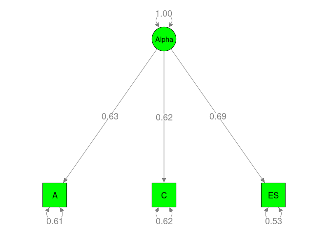

```r
## Display the model with the parameter estimates
plot(rand2, color="green")
```

## OSMASEM

```r
## Convert the data to the right format
df <- Cor2DataFrame(Digman97)

## Use subset.variables to include variables in the analysis
osmasem.fit <- osmasem(RAM=RAM, data=df, subset.variables=c("A","C","ES"))
summary(osmasem.fit)
```

```
## Summary of osmasem
##
## free parameters:
##        name  matrix row   col   Estimate  Std.Error A   z value     Pr(>|z|)
## 1  AONAlpha      A0   A Alpha  0.6273017 0.05952844   10.537847 0.000000e+00
## 2  CONAlpha      A0   C Alpha  0.6208633 0.05863687   10.588275 0.000000e+00
## 3 ESONAlpha      A0  ES Alpha  0.6887714 0.06453852   10.672253 0.000000e+00
## 4    Tau1_1 vecTau1   1     1 -3.3087018 0.41451430   -7.982118 1.332268e-15
## 5    Tau1_2 vecTau1   2     1 -3.9119737 0.43715848   -8.948640 0.000000e+00
## 6    Tau1_3 vecTau1   3     1 -4.1377834 0.46195970   -8.957022 0.000000e+00
##
## To obtain confidence intervals re-run with intervals=TRUE
##
## Model Statistics:
##                |  Parameters  |  Degrees of Freedom  |  Fit (-2lnL units)
##        Model:              6                     36             -32.37633
##    Saturated:              9                     33                    NA
## Independence:              6                     36                    NA
## Number of observations/statistics: 4496/42
##
## Information Criteria:
##       |  df Penalty  |  Parameters Penalty  |  Sample-Size Adjusted
## AIC:      -104.3763              -20.37633              -20.3576200
## BIC:      -335.1703               18.08933               -0.9763266
## To get additional fit indices, see help(mxRefModels)
## timestamp: 2023-02-01 10:09:52
## Wall clock time: 0.0308404 secs
## optimizer:  SLSQP
## OpenMx version number: 2.20.7
## Need help?  See help(mxSummary)
```

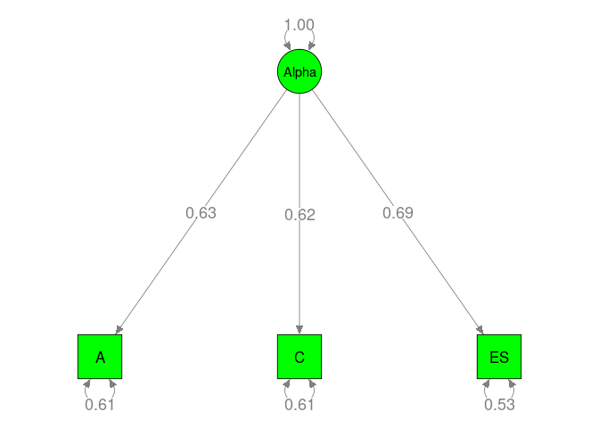

```r
plot(osmasem.fit, color="green")
```

## Summary of MASEM models

- Fixed-effects MASEM
  - `tssem1(method="FEM")`
  - `tssem1(method="REM", "Zero")`
- Fixed-effects MASEM with a categorical moderator
  - `tssem1(method="FEM", cluster)`
- Random-effects MASEM
  - `tssem1(method="REM", RE.type="Diag")`
- Regardless of what the models are, we can use the same `tssem2()` in fitting the structural equation models.
- Random-effects MASEM with a categorical or continuous moderator
  - `osmasem(method="REM", Ax)`

## Exercises

- The metaSEM package includes many sample datasets and R code for MASEM:
  - Becker09
  - Becker92
  - Becker94
  - Boer16
  - Cheung00
  - Cheung09
  - Digman97
  - Hunter83
  - issp05
  - issp89
  - Nohe15A1
  - Nohe15A2
  - Norton13
  - Roorda11
- The following papers provide [datasets and R code for MASEM](https://github.com/mikewlcheung/code-in-articles/):
  - [Cheung (2021)](https://github.com/mikewlcheung/code-in-articles/tree/master/Cheung%202021a)[^3]
  - [Cheung (2022)](https://github.com/mikewlcheung/code-in-articles/tree/master/Cheung%202022)[^4]
  - [Cheung and Hafdahl (2016)](https://github.com/mikewlcheung/code-in-articles/tree/master/Cheung%20and%20Hafdahl%202016)[^5]
  - [Cheung and Hong (2017)](https://github.com/mikewlcheung/code-in-articles/tree/master/Cheung%20and%20Hong%202017)[^6]
  - [Valentine et al. (2022)](https://github.com/jeffreycvalentine/masem-prevention_science)[^7]

# Further resources

- Questions on conducting meta-analysis in R: [R-sig-meta-analysis](https://stat.ethz.ch/mailman/listinfo/r-sig-meta-analysis)
- Questions on SEM: [SEMNET](https://listserv.ua.edu/cgi-bin/wa?SUBED1=semnet&A=1)
- Questions on the metaSEM package: [OpenMx discussion forum](https://openmx.ssri.psu.edu/forums/third-party-software/metasem)

# Discussion and Q&A

- General discussion related to meta-analysis, SEM, and MASEM.
- Do you have any specific questions related to your projects?

# Thank you!

- You have survived this workshop!

[figure not shown]

https://m.xkcd.com/1447/

[^1]: Schutte, N. S., Keng, S.-L., & Cheung, M. W.-L. (2021). Emotional intelligence (EI) mediates the connection between mindfulness and gratitude: A meta-analytic structural equation modeling study. *Mindfulness*, *12*(11), 2613–2623. https://doi.org/10.1007/s12671-021-01725-2
[^2]: Cheung, M. W.-L., & Cheung, S. F. (2016). Random-effects models for meta-analytic structural equation modeling: Review, issues, and illustrations. *Research Synthesis Methods*, *7*(2), 140–155. https://doi.org/10.1002/jrsm.1166
[^3]: Cheung, M. W.-L. (2021). Meta-analytic structural equation modeling. In Oxford Research *Encyclopedia of Business and Management*. Oxford University Press. https://doi.org/10.1093/acrefore/9780190224851.013.225
[^4]: Cheung, M. W.-L. (2022). Synthesizing indirect effects in mediation models with meta-analytic methods. *Alcohol and Alcoholism*, *57*(1), 5–15. https://doi.org/10.1093/alcalc/agab044
[^5]: Cheung, M. W.-L., & Hafdahl, A. R. (2016). Special issue on meta-analytic structural equation modeling: Introduction from the guest editors. *Research Synthesis Methods*, *7*(2), 112–120. https://doi.org/10.1002/jrsm.1212
[^6]: Cheung, M. W.-L., & Hong, R. Y. (2017). Applications of meta-analytic structural equation modelling in health psychology: Examples, issues, and recommendations. *Health Psychology Review*, *11*(3), 265–279. https://doi.org/10.1080/17437199.2017.1343678
[^7]: Valentine, J. C., Cheung, M. W.-L., Smith, E. J., Alexander, O., Hatton, J. M., Hong, R. Y., Huckaby, L. T., Patton, S. C., Pössel, P., & Seely, H. D. (2022). A primer on meta-analytic structural equation modeling: The case of depression. *Prevention Science*, *23*(3), 346–365. https://doi.org/10.1007/s11121-021-01298-5